# Introduction

Brian A. Fannin

> “Relax and embrace the chaos that is R.”

Patrick Burns

www.burns-stat.com/pages/Present/infernoishR_annotated.pdf

Does everyone have R and RStudio installed?

# What the heck is R?

While some folks are getting software sorted out, we’ll have a brief review of the history of R. Let’s get this done quick. If you don’t have R and R Studio installed, today will be a long day.

R is a programming framework designed by and for statisticians. R is …

- Free: It costs nothing to use.
- Open source: The source code is available to the public to view and modify (within restrictions).
- Extendable: Anyone may write extensions to the software. At present there are 4,000 user contributed packages and counting.
- Advanced statistical techniques are available out of the box.
- Machine learning algorithms- cluster analysis, neural networks, etc. Any time someone invents a new way to analyze data, it is quickly available in R.
- Visualize network graphs, construct word clouds, render maps. Visualization is tremendous. Bar charts and scatter plots are the tip of the iceberg. R can do it all and keeps getting better.
- Really, really cool

> “[…] R is not software, it is a community.”
- Patrick Burns

# First, there was S

[figure not shown]

# And then there was R

[figure not shown]

R was created by Ross Ihaka and Robert Gentleman as an open source alternative to S. First release in 1993.

# Nearly 40 years of development

[figure not shown]

[figure not shown]

[figure not shown]

# R package growth

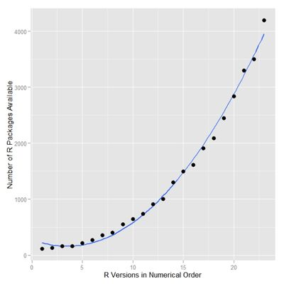

# Actuarial R packages

Several packages developed for actuarial use:

- actuar
- ChainLadder
- lossDev
- favir
- MRMR

Many articles in Variance and other publications include R code.

# Books about R for actuaries!

[figure not shown]

[figure not shown]

[figure not shown]

# What’s RStudio?

RStudio is an Integrated Development Environment (IDE). It’s not necessary, but provides quite a few nice features:

- Edit multiple scripts at a time, syntax coloring
- Manage projects, version control
- View variables in memory, debug code
- Support for package development
- Reproducible research

Does R and RStudio work for everyone?